# Labeling Brain Structures

John Muschelli

2017-12-06

All code for this document is located at [here](https://raw.githubusercontent.com/muschellij2/neuroc/master/label_image/index.R).

In Processing Within-Visit MRI we show how to register a T1-weighted image to the Eve template. The Eve template has two full brain segmentations and one white matter segmentations, each done by hand. I will refer to these as “atlases” because they tell you “where” you are in the brain with the corresponding labels.

# 1 Labels in template space

In Processing Within-Visit MRI, we registered the T1 image to the Eve template using a non-linear registration (SyN) (Avants et al. 2008). Also, we applied this transformation to the intensity-normalized T1, T2, and FLAIR images, so that these image are located in the same space as the Eve atlases. We can overlay the atlases on these registered images and look at the average intensity of each structure for each imaging sequence.

## 1.1 Reading in registered images

Here we will be reading in those previous registered, intensity-normalized images.

```r
library(neurobase)
mods = c("T1", "T2", "FLAIR")
norm_reg_files = file.path("..",
                     "preprocess_mri_within",
                     paste0("113-01-", mods, "_norm_eve.nii.gz")
                     )
names(norm_reg_files) = mods
norm_reg_imgs = lapply(norm_reg_files, readnii)
```

## 1.2 Reading in Eve brain

Here we will read in the brain-extracted Eve T1 image, the brain mask, and then mask the normalized images with this mask.

```r
library(EveTemplate)
eve_brain_fname = getEvePath("Brain")
eve_brain = readnii(eve_brain_fname)
eve_brain_mask = readEve(what = "Brain_Mask")
norm_reg_imgs = lapply(norm_reg_imgs, mask_img, mask = eve_brain_mask)
```

We will plot the registered subject images against this to ensure they are in fact in the same space. (Remember to always look at your data!)

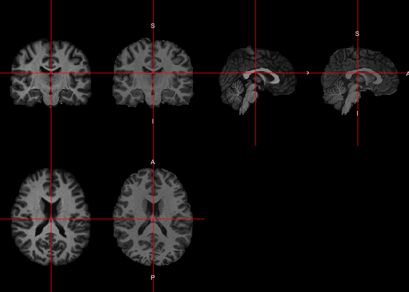

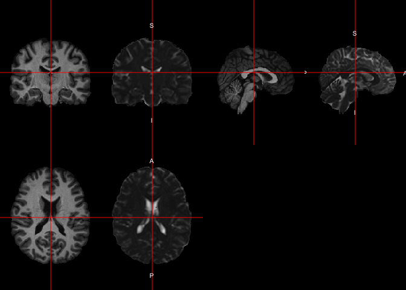

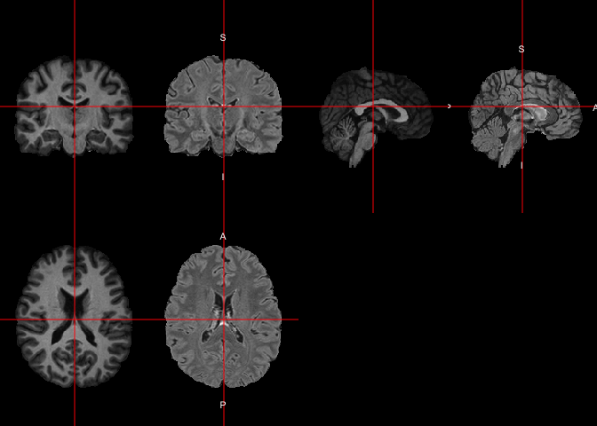

```r
lapply(norm_reg_imgs, double_ortho, x = eve_brain)
```

We see good congruence from the template and the corresponding images from this patient.

## 1.3 Getting the Eve atlas and labels

Here we will read in one of the whole brain atlases of Eve, specifically the type 2 (“II”). Please see Oishi et al. (2009) and Oishi, Faria, and Mori (2010) for further discussion of the atlases. We will read in the atlas and show that it has a series of integer labels. These labels correspond to the `integer_label` column in the `data.frame` produced by `getEveMapLabels`.

```r
eve_labels = readEveMap(type = "II")
unique_labs = eve_labels %>%
  c %>%
  unique %>%
  sort
head(unique_labs)
```

```
[1] 0 1 2 3 4 5
```

```r
lab_df = getEveMapLabels(type = "II")
head(unique(lab_df$integer_label))
```

```
[1] 0 1 2 3 4 5
```

```r
all( unique_labs %in% lab_df$integer_label)
```

```
[1] TRUE
```

## 1.4 Plotting the labels

Let’s plot the labels to see how they look.

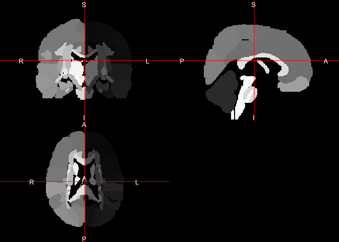

```r
ortho2(eve_labels)
```

Although that shows us the breakdown of labels, the defaults in `ortho2` are for grayscale images. Luckily, `getEveMapLabels` provides an rgb representation of a look up table (LUT) for colors for each structure. Let’s use that to plot the image:

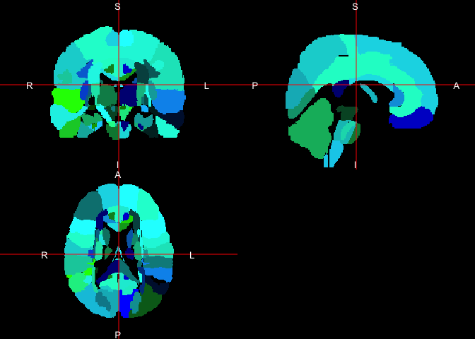

```r
cols = rgb(lab_df$color_r/255, lab_df$color_g,
           lab_df$color_b, maxColorValue = 255)
breaks = unique_labs
ortho2(eve_labels, col = cols, breaks = c(-1, breaks))
```

Again, not that great, but a bit better. We can try our own palette as below:

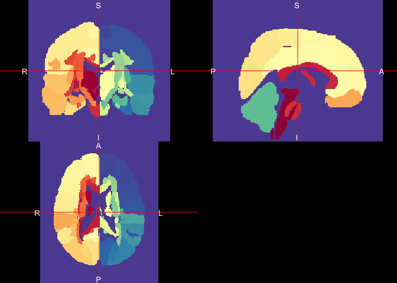

```r
library(RColorBrewer)
rf <- colorRampPalette(rev(brewer.pal(11,'Spectral')))
cols <- rf(length(unique_labs))
ortho2(eve_labels, col = cols, breaks = c(-1, breaks))
```

That may give us a good assortment of colors, where right is more red and blue is more left. We can randomize these colors, which may show better discrepancy by putting those with a blue hue close to those with red:

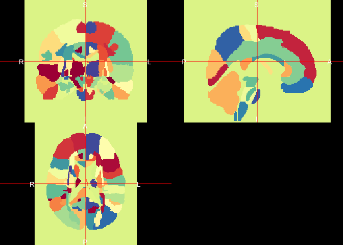

```r
set.seed(20161008)
ortho2(eve_labels, col = sample(cols), breaks = c(-1, breaks))
```

We can overlay these colors on top of the subject’s T1 image:

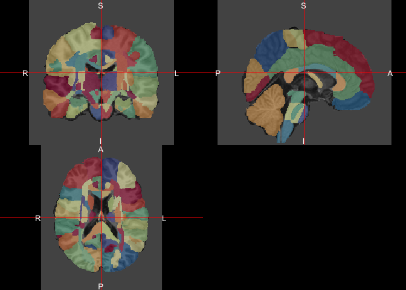

```r
set.seed(20161008)
ortho2(norm_reg_imgs$T1, eve_labels,
       col.y = alpha(sample(cols), 0.5), ybreaks = c(-1, breaks))
```

## 1.5 Getting structure-specific metrics

Now that we have our normalized images in the template/atlas space, let’s get information about each imaging sequence. Here we will make a `data.frame` with all the voxels from each modality and the atlas. There are more elegant ways to do this, but we want to be explicit below:

```r
df = data.frame(T1 = norm_reg_imgs$T1[ eve_brain_mask == 1],
                T2 = norm_reg_imgs$T2[ eve_brain_mask == 1],
                FLAIR = norm_reg_imgs$FLAIR[ eve_brain_mask == 1],
                integer_label = eve_labels[ eve_brain_mask == 1]
                )
```

Now that we have a standard `data.frame`, we can use any data manipulation procedure just as we would in any other way. Let’s reshape the data:

```r
library(reshape2)
library(dplyr)
long = reshape2::melt(df,
                      id.vars = "integer_label")
head(long)
```

```
  integer_label variable        value
1           130       T1  0.000000000
2           130       T1  0.000000000
3            65       T1 -0.006485715
4           130       T1  0.000000000
5           130       T1 -0.033087343
6           130       T1 -0.046731040
```

Now we can merge in the labels from the Eve template so that we can actually see what structures these voxels represent. We can drop the extraneous color columns as well.

```r
long = left_join(long, lab_df, by = "integer_label")
long = long %>%
  select(-color_r, -color_g, -color_b)
```

Now we can calculate some statistics:

```r
stats = long %>%
  group_by(integer_label, text_label, right_left, structure, variable) %>%
  summarise(mean = mean(value),
            median = median(value),
            sd = sd(value)) %>%
  select(variable, text_label, mean, median, sd, everything()) %>%
  ungroup
head(stats)
```

```
# A tibble: 6 x 8
  variable                    text_label         mean      median
    <fctr>                         <chr>        <dbl>       <dbl>
1       T1                    background -0.606879821 -0.69270784
2       T2                    background  1.005639427  0.21436921
3    FLAIR                    background -0.660865609 -0.32353108
4       T1 superior_parietal_lobule_left  0.105027506  0.16597870
5       T2 superior_parietal_lobule_left  0.003699062 -0.38462870
6    FLAIR superior_parietal_lobule_left  0.037216124  0.03221552
# ... with 4 more variables: sd <dbl>, integer_label <dbl>,
#   right_left <chr>, structure <chr>
```

### 1.5.1 Thalamus statistics

Let’s look at the values corresponding to the thalamus:

```r
library(stringr)
stats %>% filter(str_detect(structure, "thalamus")) %>%
  select(text_label, variable, mean) %>%
  arrange(variable, text_label)
```

```
# A tibble: 6 × 3
      text_label variable        mean
           <chr>   <fctr>       <dbl>
1  thalamus_left       T1  0.80004855
2 thalamus_right       T1  0.78460175
3  thalamus_left       T2 -0.41903584
4 thalamus_right       T2 -0.39373081
5  thalamus_left    FLAIR  0.02892382
6 thalamus_right    FLAIR  0.05632016
```

### 1.5.2 Thalamus distribution

Here we see that the thalamus has pretty consistent means for the left and the right across sequence. But what about the distrubtion of all voxels in the thalamus?

Here I’m going to define a helper function for a `ggplot2` plot, which makes legends transparent:

```r
transparent_legend =  theme(
  legend.background = element_rect(
    fill = "transparent"),
  legend.key = element_rect(fill =
                              "transparent",
                            color = "transparent")
)
```

Let’s go back to the `data.frame` `long` and plot the distribution of values for each sequence separated by left and right for the thamalus:

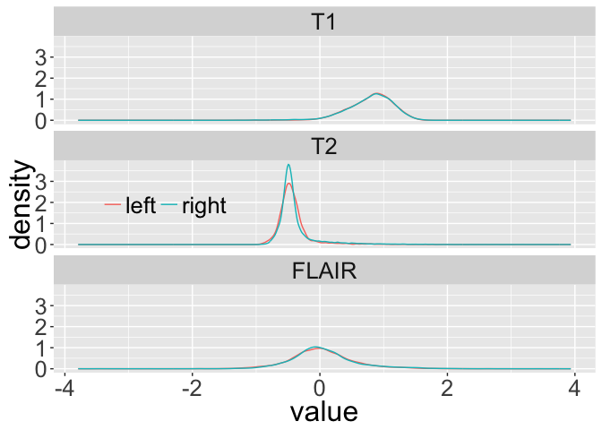

```r
 long %>% filter(str_detect(structure, "thalamus")) %>%
  ggplot(aes(x = value, colour = factor(right_left))) +
  geom_line(stat = "density") + facet_wrap(~variable, ncol = 1) +
    theme(legend.position = c(0.2, 0.5),
        legend.direction = "horizontal",
        text = element_text(size = 24)) +
  guides(colour = guide_legend(title = NULL)) +
  transparent_legend
```

We can do similar things with boxplots:

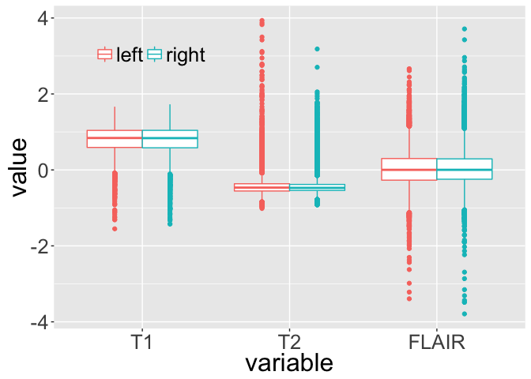

```r
 long %>% filter(str_detect(structure, "thalamus")) %>%
  ggplot(aes(x = variable, y = value, colour = factor(right_left))) +
  geom_boxplot() +
    theme(legend.position = c(0.2, 0.85),
        legend.direction = "horizontal",
        text = element_text(size = 24)) +
  guides(colour = guide_legend(title = NULL)) +
  transparent_legend
```

# 2 Labels in native space

In the above section, we registered the subject’s T1 image to the Eve template and performed all calculations and manipulations in the template space. As the SyN registration uses an affine registration as well as a non-linear component, structures are scaled and rarely stay the same size. If we want metrics of each structure, but in the **native space** (aka subject space), we can register the Eve brain to the subject space and apply the estimated transformation to the Eve atlas labels.

## 2.1 Registration of Eve to the subject T1

Here we will use the N4 corrected, processed images from Processing Within-Visit MRI and register the Eve T1 brain to the processed T1 image. Let us get the filenames that we want:

```r
eve_stub = "Eve_to_Subject"
outfile = paste0(eve_stub, "_T1.nii.gz")
lab_outfile = paste0(eve_stub, "_Labels.nii.gz")
outfiles = c(outfile, lab_outfile)

n4_files = file.path("..",
                     "preprocess_mri_within",
                     paste0("113-01-", mods, "_proc_N4_SS.nii.gz")
                     )
names(n4_files) = mods
```

Now we can register **Eve to the subject T1** (note this is the opposite from Processing Within-Visit MRI). We will use a `NearestNeighbor` interpolator here. For the Eve brain image, this may not be a good interpolation and usually we would use a windowed sinc or linear interpolator.

```r
if ( !all( file.exists(outfiles) )) {
  reg = extrantsr::registration(
    filename = eve_brain_fname,
    template.file = n4_files["T1"],
    other.files = eve_labels,
    other.outfiles = lab_outfile,
    interpolator = "NearestNeighbor",
    typeofTransform = "SyN")
}
```

```
# Running Registration of file to template
```

```
# Applying Registration output is
```

[output not shown]

```
# Applying Transformations to file
```

```
# Applying Transforms to other.files
```

```
# Writing out file
```

```
# Writing out other.files
```

```
# Removing Warping images
```

```
# Reading data back into R
```

Note, the `registration` function is somewhat limited as only one interpolator can be specified. We could break the process into registration (with an averaging interpolator for the Eve brain) and then use `extrantsr::ants_apply_transforms` to apply this transformation to the Eve labels and use a nearest-neighbor interpolator. This is how it is set up in `ANTsR` and the restriction of the `registration` function comes at the expense of having one function that performs registration and interpolation in one. In this example, we don’t care specifically about the registered-to-subject Eve template, so we don’t break the process into two.

## 2.2 Overlaying Native Eve Labels on T1

Here we will read in the output from the registered Eve labels:

```r
n4_proc_imgs = lapply(n4_files, readnii)
native_eve_labels = readnii(lab_outfile)
```

We will overlay the native Eve labels on top of the native-space N4 T1 images.

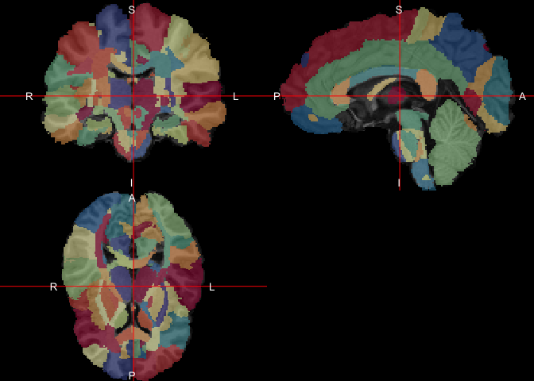

```r
set.seed(20161008)
ortho2(n4_proc_imgs$T1, native_eve_labels,
       col.y = alpha(sample(cols), 0.5),
       ybreaks = c(-1, breaks))
```